# **LSTM, Prophet, ARIMA 모형 활용 주가예측 및 성능비교**

### **작성: Joongchan Sohn @ Hanyang**

# **I. 연구의 개요**

효율적 시장 가설[1][2]의 공표 이래 금융시장에 대한 동향 예측에 여러 시도가 진행되어 왔다. 그러나, 주식 시장은 변동의 복잡성에 의해 예측하기 어렵다[3]. 이는 다양한 관점을 지닌 여러 시장 참여자들에 의해 무작위적인 소음이 포함됨에 따라 매우 복잡한 변화 양상이 있기 때문이다. 주식 시장 지수는 외교, 정치 문제 등의 외부 사건들과 개별 기업들의 사건들에 민감하다.

근래에는 대용량 데이터를 기반으로 전통적인 통계기법에 이어, 머신러닝 및 딥러닝 알고리즘을 주식 시장에 적용하고자 하는 것이 활발히 진행 중이다. 또한, 인공지능 기법은 학계 연구자들에 의해 각 모형별 성능 평가 연구에 주로 활용되고 있다. 현재 인공지능 기법을 활용한 주식 분야의 실제 예측 시도는 현재 기준 득보다 실이 많은 상황으로 현업 종사자들에 의해 알려져 있다. 국내 주식운용사들의 경우 실제 운용에는 인공지능 기법을 사용하지 않는 경우가 일반적이며, 필요시에만 제한적으로 활용되는 실정이다.

이러한 이유로, 본 연구에서는 ARIMA, Prophet, LSTM 모형을 기업 주가 예측에 적용하되, 실질적으로는 모형별 성능 평가에 주안점을 둔다.

# **II. 선행연구**

본 연구 수행 시 참고한 머신러닝 및 딥러닝 기반의 주식 분야 선행연구 사례를 제시하면 다음과 같다.

## **1.머신러닝 활용 선행연구**

주식 분야 데이터 기반의 머신러닝 기법으로 SVM(Support Vector Machine), MLP(Multi-Layered Perceptron) 등이 존재하며, 이에 대한 연구사례는 다음과 같다.

- 1,000만 개의 트위터에 대해 6가지 감성을 도출한 후, ‘Granger 인과관계 검정’ (Granger Causality Test)과 ‘자기구성 퍼지신경망’(Self-Organizing Fuzzy Neural Network)으로 미국 다우존스의 등락 예측[4]
- 재무정보를 SVM을 통해 학습하여 주가를 예측한 사례[5]
- 변동성, 모멘텀 등의 특징을 도출한 후 kNN(k-Nearest Neighbor)과 SVM을 사용하여 다음 달의 주가 지수를 예측하는 모형을 개발[6]

## **2.딥러닝 활용 선행연구**

# **III. 연구방법론**

## **1. 모형**

본 연구에서는 딥러닝 모형인 LSTM 모형과 비정상성 시계열을 예측하는 방법으로 널리 사용되는 Prophet 모형과 ARIMA 모형을 사용하였다. 주식 분야 선행연구 중 국내 KCI 저널의 검토 결과, ARIMA 모형과 LSTM 모형 활용 연구사례는 많이 있었으나, Prophet 모형의 적용 사례는 전무함에 따라, 이들 세 모형을 함께 본 연구에 적용하였다.

각 모형별 설명을 제시하면 다음과 같다.

## **가. LSTM 모형**

LSTM은 RNN 종류 중 하나인 딥러닝 모형으로 long-term dependencies 문제 해결을 위해 만들어졌으며, RNN의 은닉층에 셀 상태를 추가, 개선한 모형이다[10]. 과거 학습 정보를 기억하여 새로운 학습 결과에 반영할 수 있다. 즉, LSTM 모형은 시계열 데이터 예측에 좋은 성능을 발휘 가능한 모형이다.

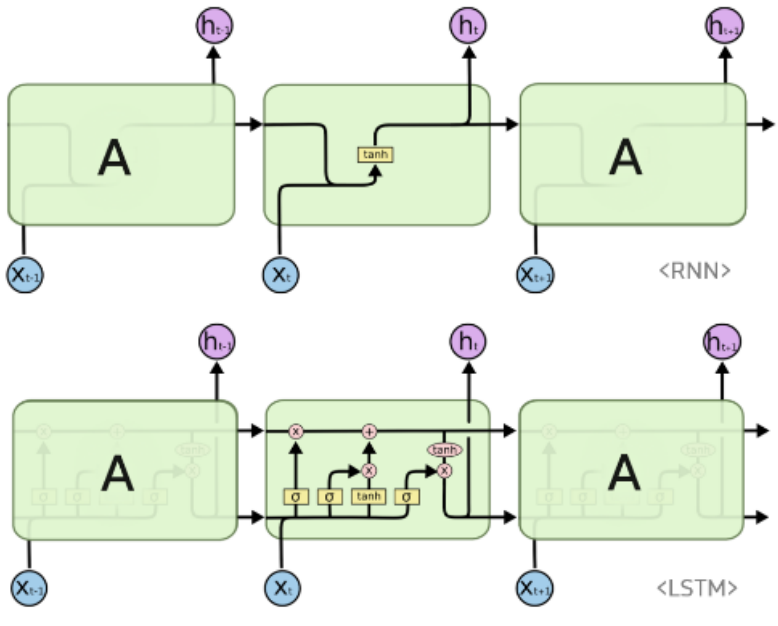

**[그림 1] LSTM 모형의 구조**

## **나. Prophet 모형**

Facebook이 제공하는 라이브러리 모형으로, 비선형 데이터를 사용하여 일간, 주간, 연간 주기를 기준으로 추세를 파악하여 제시할 수 있다[14]. 특히, 다음의 경우에 실제 데이터와 유사한 예측 결과를 제공한다고 알려져 있다.

- 과거 장기적인 추이로 이후 추세를 대략적으로 파악하는 경우
- 데이터상 갑작스러운 변동사항이 없는 경우

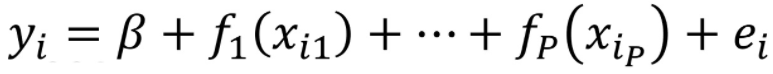

  **[식 1] Prophet 모형**

## **다. ARIMA 모형**

ARMA(AutoRegression Moving Average) 모형에 Integrated 개념을 추가한 모형이며, 이 때, ARMA 모형은 AR(AutoRegression) 모형과 MA(Moving Average) 모형를 섞은 모형으로, 과거 상태, 오차값을 통해 현재 상태를 예측한다[14]. AR 모형과 MA 모형은 다음과 같다.

- AR 모형은 자기회귀모형으로, ‘이전의 관측값이 이후 자신의 관측값에 영향을 준다’는 아이디어에 기초한 모형이다.
- MA 모형은 이동평균모형으로, 평균이 변할 때 적합한 회귀모형으로서 이전 항의 오차를 이용하여 현재 항의 상태를 추론하는 모형이다.

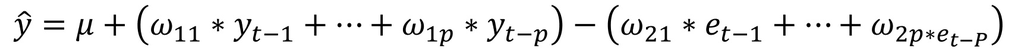

## **2. 데이터 및 분석방법**

## **가. 주가예측 대상기업**

RE100('Renewable Electricity 100’과 ‘Renewable Energy 100’을 함께 혼용) 캠페인에 가입한 전 세계 기업 중 국내 1개사를 주가예측 대상기업으로 선정하였다.  
RE100 캠페인은 전 세계적으로 파리 협정에 따라 전력시스템의 목표 탈탄소화 비율을 달성하기 위해, 기업들이 자발적으로 2050년까지 사용전력의 100%를 재생에너지로 사용하는 것을 선언하는 캠페인[15]이다. 본 캠페인은 현재 국제 비영리기구인 The Climate Group이 운영한다.  
본 캠페인에서 기업의 참여자격은 연간 0.1 TW(Terawatt) 이상의 전력을 사용하는 기업, 포춘 100 기업 등 국내외 영향력이 있는 기업이다. ’21년 12월 현재기준 전 세계 가입기업은 총 346개사로, 이 중 국내 가입기업은 8개사이다. 국내 8개사는 RE100을 가입완료한 국내 기업으로, 현재 가입대기 상태임에 따라 아직 사이트 목록에 없는 국내 기업은 제외한다.  
본 연구에서 주가예측 대상기업은 국내 가입기업 8개사 중 가입이 가장 빠르고(2020년 가입), RE100 사이트 내에서 Gold Member 업체로 제시된 **“SK telecom”**이다.

[figure not shown]

**[그림 2] 2020년 RE100 캠페인에 가입한 국내 기업**  
*재구성: The Climate Group, “RE100”(https://www.there100.org).

## **나. 주가 데이터**

주가 데이터로 편리하게 활용 가능한 API는 다음의 2가지가 있다.

- Yahoo Finance API (yfinance Package)
- FinanceDataReader Package

본 연구에서는 Yahoo Finance API를 활용하였다.

## **다. Training/Test sets**

본 연구에서 Training set과 Test set은 각각 0.8 : 0.2를 적용하였다.

## **라. 분석기간**

분석기간은 2012.01.01. ~ 2021.11.30. (9년 11개월)이다.

# **IV. 연구결과**

## **1. 종합 결과**

본 연구에서 사용된 세 모형에 대한 성능평가의 종합 결과는 MSE 기준, LSTM < Prophet < ARIMA로 나타났다. 즉, 본 연구에서 상기 3개의 모형의 성능을 주가 예측을 통해 측정한 결과, MSE가 가장 적은 LSTM 모형이 가장 우수한 성능의 모형인 것으로 확인되었다.

**<표 1> 모형 성능평가 결과 종합**

| 구 분 | MSE | RMSE |
| --- | --- | --- |
| **LSTM** | 341661.183 | 584.518 |
| Prophet | 1470309.209 | 1211.238 |
| ARIMA | 7034087.778 | 2652.185 |

## **2. 모형별 성능 평가 결과**

앞서 제시한 기준에 따라 SK telecom사에 대한 최근 9년 11개월간의 주가 예측 및 성능 평가 결과는 다음과 같다.

## **가. LSTM 모형 결과**

LSTM 모형을 활용한 연구결과, MSE가 341661.183 이었고, RMSE는 584.518 로 나타났다.

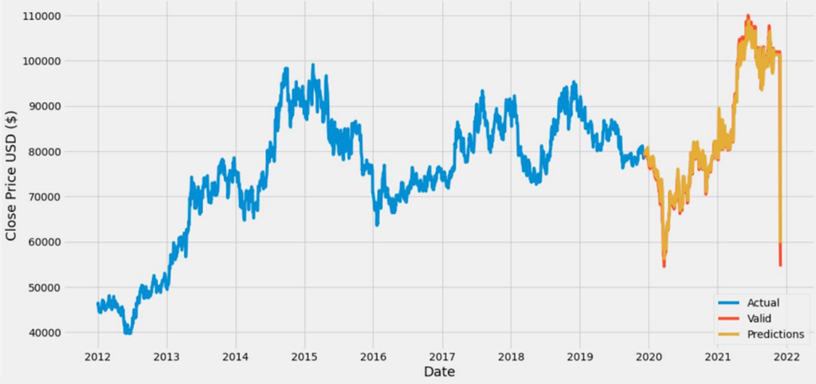

**[그림2] LSTM 모형 결과**

## **나. Prophet 모형 결과**

Prophet 모형을 활용한 연구결과, MSE가 1470309.209 이었고, RMSE는 1211.238 로 나타났다.

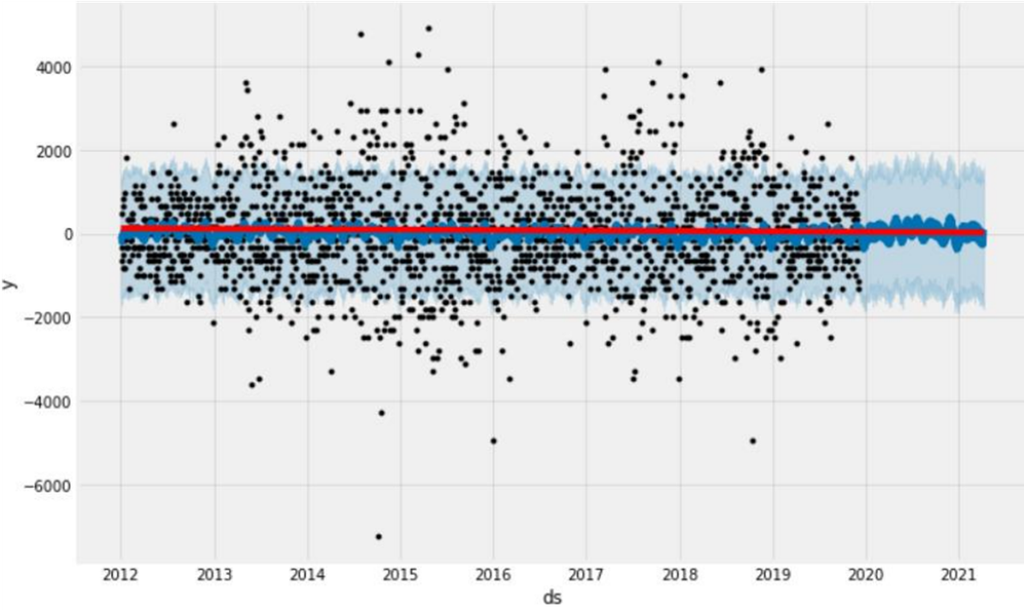

**[그림 3] Prophet 모형 결과**

## **다. ARIMA 모형 결과**

ARIMA 모형을 활용한 연구결과, MSE가 7034087.778 이었고, RMSE는 2652.185 로 나타났다.

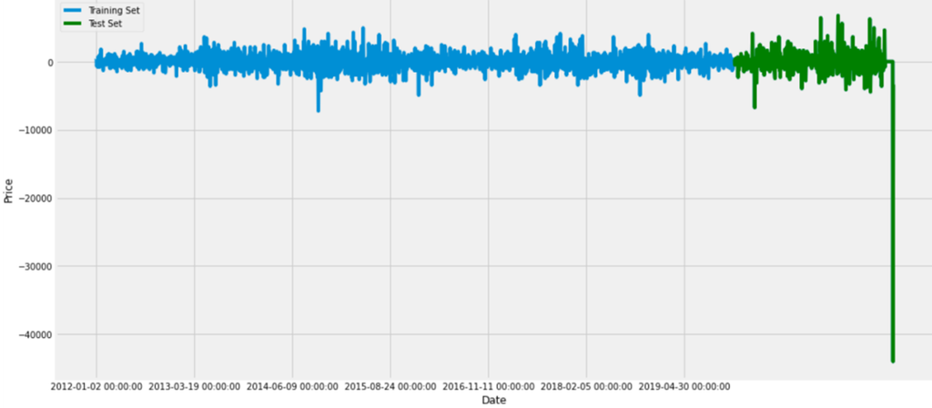

**[그림 4] ARIMA 모형 결과**

# **V. 연구의 한계 및 향후 계획**

보통 과거의 선행연구 사례에서 ARIMA 모형이 LSTM 모형보다 시계열 데이터 예측 시 뛰어난 예측을 보이는 것으로 확인하였으나, 본 연구에서는 우수한 성능을 보여준 모형이 LSTM 모형인 것으로 나타나, 추후 본 연구에 사용된 파이썬 코드의 이해와 검증이 요구된다.

이 밖에도 과거 선행연구 사례들에서 공개되어 있는 파이썬 코드들의 재현연구 시 발생한 여러 에러코드들에 대해 기민한 대처가 가능하도록 근본적인 파이썬 실력을 증진시키도록 노력할 계획이다.

특히, 본인의 향후 연구 방향과 관련해서 파이썬의 학습은 필수적임에 따라, 금년 겨울방학 동안 빅데이터 수업 영상과 한 학기 동안 연습했던 코드들을 복습하도록 하겠다.

# **< 참고문헌 >**

[1] Cootner. P. H (1964). The Random Character of Stock Market Prices.  
[2] Malkiel. B. G & Fama. E. F (1970). Efficient Capital Markets: A Review of Theory and Empirical Work, *The Journal of Finance*, 25(2), 383-417.  
[3] 이시운 (2020). 대량 금융데이터를 이용한 주가 종합지수 예측, *아주대학교 대학원*.  
[4] J. Bollen & H. Mao & X. Zeng (2011). Twitter Mood Predicts the Stock Market, *Journal of Computational Science*, 2(1), 1-8.  
[5] J. Y. Heo & J. Y. Yang (2015). SVM based Stock Price Forecasting Using Financial Statements, *KIISE Transactions on Computing Practices*, 21(3), 167-172.  
[6] G. B. Nam et al. (2017). Development of Stock Investment System Using Machine Learning, *2017 Proceeding of Information Processing Society Fall Conference*, 24(2), 810-812.  
[7] Ashwin Siripurapu (2015). Convolutional Networks for Stock Trading, *Stanford University*.  
[8] 신동하외3 (2017). RNN과 LSTM을 이용한 주가 예측율 향상을 위한 딥러닝 모델, *한국정보기술학회논문지*.  
[9] H. J. Kim et al. (2018). Stock Price Prediction Using Deep Learning Ensemble, *SIGDB*, 34(2), 113-120.  
[10] 정종진‧김지연 (2020). LSTM을 이용한 주가예측 모델의 학습방법에 따른 성능분석, *디지털융복합연구*, vol.18, no.11, pp.259-266.  
[11] 오승원외3 (2020). Prophet 모형을 이용한 마늘 가격의 장기예측 및 트렌드 분석, *한국자료분석학회*.  
[12] 임준형외1 (2020). 산업군별 온라인 뉴스에 기초한 감성 예측변수를 포함하는 심층 신경망 모형에 의한 주가 예측, *응용통계연구*.  
[13] 조유정외2 (2021). 인공지능의 사회적 수용도에 따른 키워드 검색량 기반 주가예측모형 비교연구, *지능정보연구*.  
[14] 서진영. 통계적 기법(ARIMA, Prophet), http://www.rex-ai.info/docs/AI_study_statistic.  
[15] The Climate Group. RE100, https://www.there100.org.